# Illustration of Bagging

using Example 2.8 (page 65)

Tong Wang

October 2017

## Introduction

In this note, we illustrate Bagging of trees by replicating Example 2.8 in the textbook. The only extra add-on is that we will introduce an extra noise term $\epsilon$ in the target.

## The Data Generating Model

Under the data generating model specified in Example 2.8, $x \sim U[-1, 1]$ and $f(x) = \sin(\pi x)$. We introduce noise $\epsilon \sim N(0, \sigma^2)$ and let $y = f(x) + \epsilon$. Let’s set a bit larger noise $\sigma=0.5$ for this illustration.

```r
set.seed(135790)
# static parameters
x.min <- -1
x.max <- 1
sigma <- 0.5
# function for generating data
data.gen <- function(N=2) {
    x <- runif(n=N, min=x.min, max=x.max)
    f.x <- sin(pi * x)
    epsilon <- rnorm(n=N, mean=0, sd=sigma)
    y <- f.x + epsilon
    return(data.frame(x=x, y=y))
}
```

We will first generate a big out-of-sample dataset from the same population; later it will be needed to evaluate the out-of-sample performance.

```r
M <- 10000
x.out <- sort(runif(n=M, min=x.min, max=x.max))  # order the data points by x for easy plots
f.x.out <- sin(pi * x.out)
y.out <- f.x.out + rnorm(n=M, mean=0, sd=sigma)
data.out <- data.frame(x=x.out, y=y.out)
```

## The Hypothesis Sets

### Hypothesis 0: constant prediction

The $\mathcal{H}_0$ predicts a constant, and given a data sample, the best hypothesis in $\mathcal{H}_0$ will be predicting the mean $\bar{y}$.

```r
# function to generate constant prediction
h0 <- function(data) {
    return(c(mean(data$y), 0))  # return the intercept and slope as a vector (slope is zero)
}
```

### Hypothesis 1: linear prediction

The $\mathcal{H}_1$ fits a line based on the data.

```r
# function to generate line prediciton
h1 <- function(data) {
    lr <- lm(y ~ x, data)  # run a linear regression over the N data points
    return(coef(lr))  # return the intercept and slope
}
```

### Hypothesis 3: tree

The hypothesis of interest is tree. Note here that the tree structure can differ from one to another, so we simply keep a record of the prediction on the test data of each tree.

```r
# function to generate tree prediciton
h3 <- function(data.train, data.test) {
    tree.fit <- tree(y ~ x, data.train)  # run a regression tree over the N data points
    return(predict(tree.fit, newdata=data.test))
}
```

## One Single Data Sample

First, let’s see what would happen if we just stick to a single data sample. Let’s fix $N=50$ here.

```r
N <- 50
set.seed(4680)
data0 <- data.gen(N=N)
coef.h0 <- h0(data0)
coef.h1 <- h1(data0)
yhat.out.h3 <- h3(data0, data.out)
```

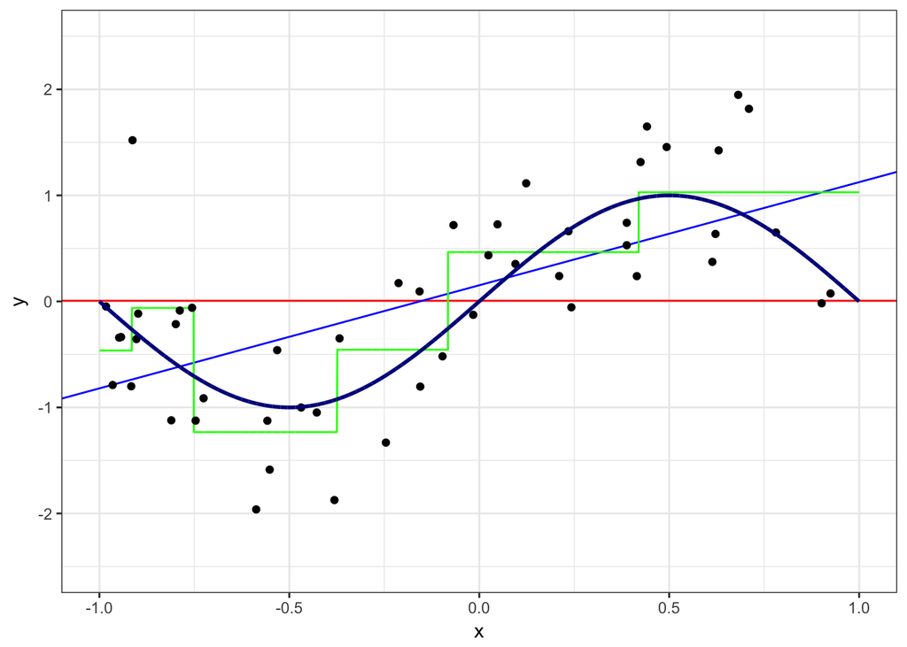

```r
x.lim <- c(x.min, x.max)
y.lim <- c(-2.5, 2.5)
ggplot()  + geom_abline(intercept=coef.h0[1], slope=coef.h0[2], color="red") +
    geom_abline(intercept=coef.h1[1], slope=coef.h1[2], color="blue") +
    geom_line(aes(x=x.out, y=yhat.out.h3), color="green") +
    geom_point(data=data0, aes(x=x, y=y)) +
    geom_line(aes(x=x.out, y=f.x.out), color="darkblue", size=1) + labs(x="x", y="y") +
    coord_cartesian(ylim=y.lim, xlim=x.lim) + theme_bw()
```

## Averaging Hypotheses over Bootstrap Samples

Now suppose we do not have access to the data generating model and hence cannot simulate more data samples from the population. We can still obtain similar result by the bootstrap: draw many (RUN=1000) bootstrap samples based on the data we have on-hand and generate predictions and compare the two hypothesis sets.

```r
# function for generating Bootstrap data sample
data.bootstrap <- function(data) {
    index <- sample(N, N, replace=TRUE)
    return(data[index, ])
}
```

```r
RUN <- 1000
g0_D.bs <- matrix(NA, nrow=RUN, ncol=2)  # output of H0
g1_D.bs <- matrix(NA, nrow=RUN, ncol=2)  # output of H1
g3_D_x.bs <- matrix(NA, nrow=RUN, ncol=M)  # test prediction of all the trees
for (run in 1:RUN){
    data <- data.bootstrap(data=data0)
    g0_D.bs[run, ] <- h0(data)
    g1_D.bs[run, ] <- h1(data)
    g3_D_x.bs[run, ] <- h3(data, data.out)
}
```

### Individual Hypotheses

We can visualize the 1000 final hypotheses $g_0^{(D)}$, $g_1^{(D)}$, and $g_3^{(D)}$ together with the true function $f(x)$ (in blue).

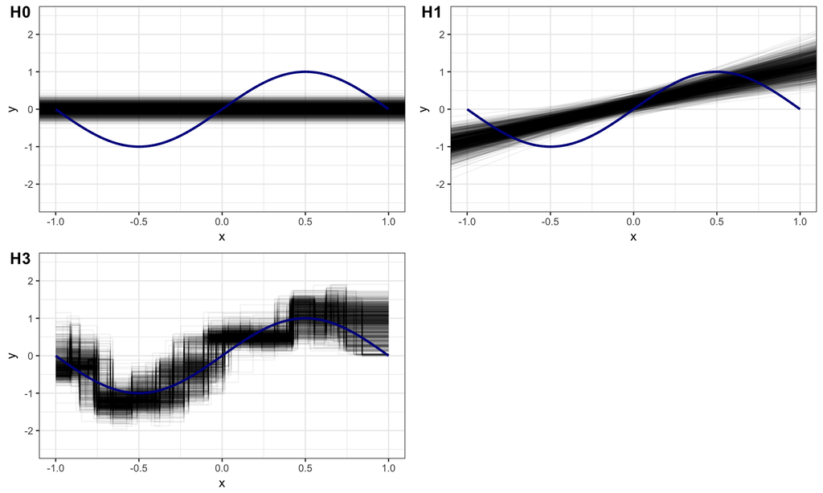

```r
plot0 <- ggplot() + geom_abline(intercept=g0_D.bs[, 1], slope=g0_D.bs[, 2], alpha=0.05) + geom_line(aes(x=x.out, y=f.x.out), color="darkblue", size=1) + labs(x="x", y="y") + coord_cartesian(ylim=y.lim, xlim=x.lim) + theme_bw()

plot1 <- ggplot() + geom_abline(intercept=g1_D.bs[, 1], slope=g1_D.bs[, 2], alpha=0.05) + geom_line(aes(x=x.out, y=f.x.out), color="darkblue", size=1) + labs(x="x", y="y") + coord_cartesian(ylim=y.lim, xlim=x.lim) + theme_bw()

# reshape the tree prediction data for plotting
data3 <- as.data.frame(g3_D_x.bs)
colnames(data3) <- x.out
data3$run <- 1:RUN
data3.long <- data3 %>% gather(key=x.out, value=yhat, -run)
data3.long$x.out <- as.numeric(data3.long$x.out)

plot3 <- ggplot() + geom_line(data=data3.long, aes(x=x.out, y=yhat, group=run), alpha=0.05) + geom_line(aes(x=x.out, y=f.x.out), color="darkblue", size=1) + labs(x="x", y="y") + coord_cartesian(ylim=y.lim, xlim=x.lim) + theme_bw()

cowplot::plot_grid(plot0, plot1, plot3, labels=c("H0", "H1", "H3"), align="h")
```

### Average Hypotheses

We can also visualize the “average” hypotheses $\bar{g}_0(x)$ and $\bar{g}_1(x)$ and also their “variability” over another bigger data sample “x.out”, which is to approximate the population. By definition, $\bar{g}(x) = \text{E}_D [g^{(D)}(x)]$, so we need to average out over $D$ while keeping the dependency on $x$. Similarly, we can measure variability over $D$ by $\text{SD}_D [g^{(D)}(x)]$.

```r
# for H0
g0_D_x.bs <- g0_D.bs %*% t(cbind(1, x.out))
g0_bar_x.bs <- colMeans(g0_D_x.bs)
g0_sd_x.bs <- apply(g0_D_x.bs, 2, sd)  # apply "sd" columnwise
# for H1
g1_D_x.bs <- g1_D.bs %*% t(cbind(1, x.out))
g1_bar_x.bs <- colMeans(g1_D_x.bs)
g1_sd_x.bs <- apply(g1_D_x.bs, 2, sd)  # apply "sd" columnwise
# for H3
g3_bar_x.bs <- colMeans(g3_D_x.bs)
g3_sd_x.bs <- apply(g3_D_x.bs, 2, sd)  # apply "sd" columnwise
```

With the above, we can visualize the “average” and “variability” as a function of $x$.

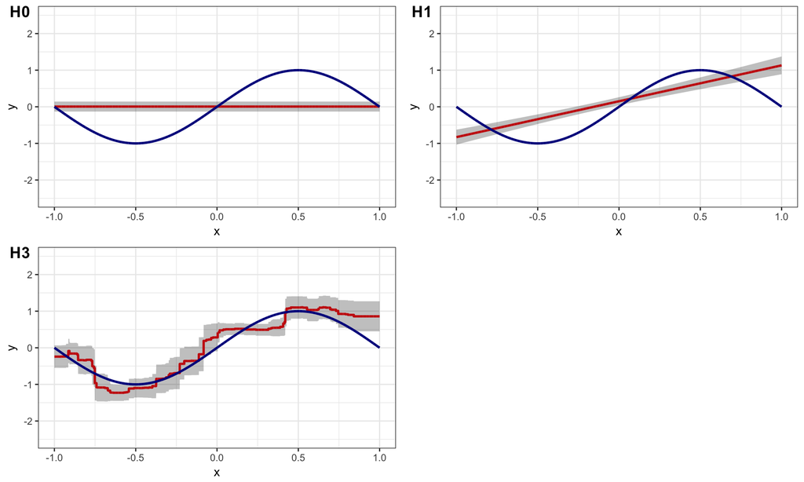

```r
plot0_bar <- ggplot() + geom_line(aes(x=x.out, y=g0_bar_x.bs), color="red", size=1) + geom_ribbon(aes(x=x.out, ymin=g0_bar_x.bs - g0_sd_x.bs, ymax=g0_bar_x.bs + g0_sd_x.bs), alpha=0.3) + geom_line(aes(x=x.out, y=f.x.out), color="darkblue", size=1) + labs(x="x", y="y") + coord_cartesian(ylim=y.lim, xlim=x.lim) + theme_bw()

plot1_bar <- ggplot() + geom_line(aes(x=x.out, y=g1_bar_x.bs), color="red", size=1) + geom_ribbon(aes(x=x.out, ymin=g1_bar_x.bs - g1_sd_x.bs, ymax=g1_bar_x.bs + g1_sd_x.bs), alpha=0.3) + geom_line(aes(x=x.out, y=f.x.out), color="darkblue", size=1) + labs(x="x", y="y") + coord_cartesian(ylim=y.lim, xlim=x.lim) + theme_bw()

plot3_bar <- ggplot() + geom_line(aes(x=x.out, y=g3_bar_x.bs), color="red", size=1) + geom_ribbon(aes(x=x.out, ymin=g3_bar_x.bs - g3_sd_x.bs, ymax=g3_bar_x.bs + g3_sd_x.bs), alpha=0.3) + geom_line(aes(x=x.out, y=f.x.out), color="darkblue", size=1) + labs(x="x", y="y") + coord_cartesian(ylim=y.lim, xlim=x.lim) + theme_bw()

cowplot::plot_grid(plot0_bar, plot1_bar, plot3_bar, labels=c("H0", "H1", "H3"), align="h")
```

The Bagging model predicts with the average of the trees, i.e., **g3_bar_x.bs**, and the resulted MSE of this individual Bagging model is

```r
mse3 <- mean((t(g3_bar_x.bs) - y.out)^2)
mse3
```

```
## [1] 0.3274218
```

### Error Measures

In order to say something about the Bias and Variance, we need to repeat the Bagging process (of 500 trees) many times. Let call it $\mathcal{H}_4$.

```r
# function to generate Bagging prediciton
h4 <- function(data.train, data.test, ntree=500) {
    N <- nrow(data.train)
    M <- nrow(data.test)
    tree.pred <- matrix(NA, nrow=ntree, ncol=M)
    for (t in 1:ntree){
        index <- sample(N, N, replace=TRUE)
        tree.fit <- tree(y ~ x, data.train[index,])
        tree.pred[t, ] <- predict(tree.fit, newdata=data.test)
    }

    return(colMeans(tree.pred))
}

g0_D <- matrix(NA, nrow=RUN, ncol=2)  # output of H0
g1_D <- matrix(NA, nrow=RUN, ncol=2)  # output of H1
g4_D_x <- matrix(NA, nrow=RUN, ncol=M)  # output of Bagging
for (run in 1:RUN){
    data <- data.gen(N=N)
    g0_D[run, ] <- h0(data)
    g1_D[run, ] <- h1(data)
    g4_D_x[run, ] <- h4(data, data.out)
}

# for H0
g0_D_x <- g0_D %*% t(cbind(1, x.out))
g0_bar_x <- colMeans(g0_D_x)
g0_sd_x <- apply(g0_D_x, 2, sd)  # apply "sd" columnwise
# for H1
g1_D_x <- g1_D %*% t(cbind(1, x.out))
g1_bar_x <- colMeans(g1_D_x)
g1_sd_x <- apply(g1_D_x, 2, sd)  # apply "sd" columnwise
# for H4
g4_bar_x <- colMeans(g4_D_x)
g4_sd_x <- apply(g4_D_x, 2, sd)  # apply "sd" columnwise
```

Finally, we can calculate the Bias, Variance, and total MSE. Recall that
$$\text{Bias} = \text{E}_x \left[ (\bar{g}(x) - f(x))^2 \right];~~~~~ \text{Variance} = \text{E}_x \text{E}_D \left[ (g^{(D)}(x) - \bar{g}(x))^2 \right];~~~~~ \text{MSE} = \text{E}_x \text{E}_D \left[ (g^{(D)}(x) - y)^2 \right].$$

For $\mathcal{H}_0$,

```r
bias0 <- mean((g0_bar_x - f.x.out)^2)
variance0 <- mean((g0_D_x - g0_bar_x)^2)
mse0 <- mean((t(g0_D_x) - y.out)^2)
```

for $\mathcal{H}_1$,

```r
bias1 <- mean((g1_bar_x - f.x.out)^2)
variance1 <- mean((t(g1_D_x) - g1_bar_x)^2)
mse1 <- mean((t(g1_D_x) - y.out)^2)
```

and for $\mathcal{H}_4$,

```r
bias4 <- mean((g4_bar_x - f.x.out)^2)
variance4 <- mean((t(g4_D_x) - g4_bar_x)^2)
mse4 <- mean((t(g4_D_x) - y.out)^2)
```

The final numbers are as follows.

| Hypothesis Set | Bias | Variance | Irreducible Error | MSE |
| --- | --- | --- | --- | --- |
| $\mathcal{H}_0$: constant | 0.5043474 | 0.0139298 | 0.2408858 | 0.759163 |
| $\mathcal{H}_1$: linear | 0.1926674 | 0.0199761 | 0.2483876 | 0.4610311 |
| $\mathcal{H}_4$: bagging | 0.0089205 | 0.0467703 | 0.250438 | 0.3061287 |